# Qualtrics in R

Jason

## Introduction - Qualtrics and R

Are you working in R and use Qualtrics surveys? Have your fingers fallen off from downloading each Qualtrics survey individually? Well, you have come to the right place.

And for those of you who don’t know what’s going on? Well, hello! You might be wondering what this whole “Qualtrics” and “R” jazz is about. R is a programming language that’s often used for statistical analysis. Qualtrics is a platform that allows users to design and collect survey data. Why do we want to mix the two?

To work your statistical magic in R, you have to get down and dirty with data. But where do you get it from? You get the idea. If you have data in Qualtrics, they have a handy interface to download your collected survey data in its webpage navigation.

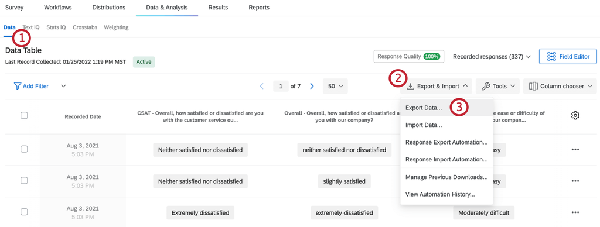

You can fiddle with the options, hit download, and voila, you have your data. Now do that for every survey. Or in my case, some 36 surveys for a research study.

## Overview

Here’s an overview of what we’ll do.

```r
library(DiagrammeR)
library(tidyverse)
```

```r
DiagrammeR::grViz("digraph {
  graph [layout = dot, rankdir = BT]

  node [shape = rectangle]
  rec1 [label = 'Objective: Data is ready']
  rec2 [label = 'Needs code query']
  rec3 [label =  'Needs QualtRics set up']
  rec4 [label = 'Needs API token set up']

  rec1 -> rec2 -> rec3 -> rec4
  }",
  height = 400)
```

[interactive chart not shown]

So this is how we’ll approach it.

```r
DiagrammeR::grViz("digraph {
  graph [layout = dot, rankdir = TB]

  node [shape = rectangle]
  rec1 [label = 'Objective: Data is ready']
  rec2 [label = 'Step 3: Write some code']
  rec3 [label =  'Step 2: Set up QualtRics']
  rec4 [label = 'Step 1: Set up token key']

  rec4 -> rec3 -> rec2 -> rec1
  }",
  height = 400)
```

[interactive chart not shown]

## Step 1: Qualtrics API token

For my non-technical friends out there: think of Qualtrics as our house of data, and the Application Programming Interface (API) as their door. We can get our data if we knock on their door, but we have to prove we aren’t strangers. That’s where the API token comes in, it’s our identification card!

You can access the token generation page by clicking on account settings.

[figure not shown]

Once you’re in the account settings, you can click on Qualtrics IDs and then generate token from there.

[figure not shown]

*Warning* If you don’t see the token generation, it’s likely that your account has restricted access. Please contact your IT crew or whoever manages the Qualtrics subscription to enable it for you.

[figure not shown]

Once you have successfully generated your token, keep it handy because we’re going to use it soon! For more details on the API token, please see [Qualtrics’ guide](https://www.qualtrics.com/support/integrations/api-integration/overview/)

## Step 2: QualtRics

As you can imagine, talking to an API ain’t easy. You got to do some GET requests, learn it in R, learn about the particulars of Qualtrics’ API. Luckily for us, there’s a package called [QualtRics](https://github.com/ropensci/qualtRics) that’s done the hard work for us. All we have to do is set up our API token from earlier and use their library commands.